# Kapitola 13: Logistická regresia

Bayes Rules! An Introduction to Applied Bayesian Modeling

Študijné materiály

2025-12-03

# 1 Úvod do logistickej regresie

V kapitole 12 sme sa naučili, že nie každá regresia je Normálna. V kapitole 13 čelíme ďalšiemu faktu: **nie každá závislá premenná $Y$ je kvantitatívna**.

Môžeme chcieť modelovať:

- $Y$ = či spevák vyhrá Grammy, podľa recenzií albumu
- $Y$ = či osoba bude voliť, podľa veku a politického presvedčenia

V týchto príkladoch, a v klasifikačných úlohách všeobecne, je $Y$ **kategorická premenná**.

## 1.1 Prípadová štúdia: Predpoveď dažďa v Perthe

Nachádzame sa v Austrálii, konkrétne v meste Perth. Naším cieľom bude **predpovedať, či bude zajtra pršať**.

Závislá premenná $Y$ je binárna kategorická premenná:

$$Y = \begin{cases} 1 & \text{ak
zajtra prší} \\ 0 & \text{inak} \end{cases}$$

**Potenciálne prediktory:**

- $X_1$ = dnešná vlhkosť o 9:00 ráno (%)
- $X_2$ = dnešná vlhkosť o 15:00 (%)
- $X_3$ = či dnes pršalo

**Náš apriorný odhad:**

- Priemerný deň má približne 20% šancu na dážď
- Šanca na dážď sa zvyšuje s vysokou vlhkosťou alebo ak už pršalo

## 1.2 Načítanie balíkov a dát

```r
# Načítanie potrebných balíkov
library(bayesrules)
library(rstanarm)
library(bayesplot)
library(tidyverse)
library(tidybayes)
library(broom.mixed)
library(janitor)
```

```r
# Načítanie a príprava dát
data(weather_perth)
weather <- weather_perth %>%
  select(day_of_year, raintomorrow, humidity9am, humidity3pm, raintoday)

# Prehľad dát
head(weather)
```

```
## # A tibble: 6 × 5
##   day_of_year raintomorrow humidity9am humidity3pm raintoday
##         <dbl> <fct>              <int>       <int> <fct>
## 1          45 No                    55          44 No
## 2          11 No                    43          16 No
## 3         261 Yes                   62          85 No
## 4         347 No                    53          46 No
## 5         357 No                    65          51 No
## 6         254 No                    84          59 Yes
```

```r
dim(weather)
```

```
## [1] 1000    5
```

```r
# Rozdelenie závislej premennej
table(weather$raintomorrow)
```

```
##
##  No Yes
## 814 186
```

```r
prop.table(table(weather$raintomorrow))
```

```
##
##    No   Yes
## 0.814 0.186
```

# 2 Odds (šanca) a pravdepodobnosť

Pred samotnou logistickou regresiou si zopakujme koncept **odds (šanca)** a jeho vzťah k pravdepodobnosti.

## 2.1 Definícia odds

Nech $\pi$ je pravdepodobnosť udalosti. Potom **odds** (šanca) tejto udalosti je definovaná ako:

$$\text{odds} =
\frac{\pi}{1-\pi}$$

**Kľúčové rozdiely:**

| Miera | Rozsah hodnôt |
| --- | --- |
| Pravdepodobnosť $\pi$ | $[0, 1]$ |
| Odds $\frac{\pi}{1-\pi}$ | $[0, \infty)$ |

## 2.2 Príklady interpretácie odds

### 2.2.1 Príklad 1: Pravdepodobnosť dažďa = 2/3

$$\text{odds dažďa} = \frac{2/3}{1-2/3} =
\frac{2/3}{1/3} = 2$$

**Interpretácia:** Je **dvakrát** pravdepodobnejšie, že bude pršať, ako že nebude.

### 2.2.2 Príklad 2: Pravdepodobnosť dažďa = 1/3

$$\text{odds dažďa} = \frac{1/3}{1-1/3} =
\frac{1/3}{2/3} = \frac{1}{2}$$

**Interpretácia:** Je **polovica** tak pravdepodobné, že bude pršať, ako že nebude.

### 2.2.3 Príklad 3: Pravdepodobnosť dažďa = 1/2

$$\text{odds dažďa} = \frac{1/2}{1-1/2} =
\frac{1/2}{1/2} = 1$$

**Interpretácia:** Je **rovnako** pravdepodobné, že bude alebo nebude pršať.

## 2.3 Pravidlá pre interpretáciu odds

> **Interpretácia odds:**
> - **odds < 1** $\Leftrightarrow$ $\pi < 0.5$ (udalosť je nepravdepodobná)
> - **odds = 1** $\Leftrightarrow$ $\pi = 0.5$ (50-50 šanca)
> - **odds > 1** $\Leftrightarrow$ $\pi > 0.5$ (udalosť je pravdepodobná)

## 2.4 Konverzia odds na pravdepodobnosť

Z odds môžeme získať pravdepodobnosť:

$$\pi = \frac{\text{odds}}{1 +
\text{odds}}$$

**Príklad:** Ak odds dažďa = 4, potom:

$$\pi = \frac{4}{1 + 4} = \frac{4}{5} =
0.8$$

```r
# Praktické výpočty
prob_to_odds <- function(p) p / (1 - p)
odds_to_prob <- function(odds) odds / (1 + odds)

# Príklady
tibble(
  pravdepodobnost = c(0.1, 0.2, 0.33, 0.5, 0.67, 0.8, 0.9),
  odds = prob_to_odds(pravdepodobnost),
  log_odds = log(odds)
) %>%
  mutate(across(where(is.numeric), ~round(., 3)))
```

```
## # A tibble: 7 × 3
##   pravdepodobnost  odds log_odds
##             <dbl> <dbl>    <dbl>
## 1            0.1  0.111   -2.20
## 2            0.2  0.25    -1.39
## 3            0.33 0.493   -0.708
## 4            0.5  1        0
## 5            0.67 2.03     0.708
## 6            0.8  4        1.39
## 7            0.9  9        2.20
```

# 3 Budovanie modelu logistickej regresie

## 3.1 Špecifikácia dátového modelu

Nech $Y_i$ je indikátor 0/1, či zajtra prší pre deň $i$. Modelujeme $Y_i$ pomocou prediktora - dnešnej rannej vlhkosti $X_{i1}$.

### 3.1.1 Výber vhodného rozdelenia

**Otázka:** Aká je vhodná štruktúra modelu pre dáta $Y_i$?

Keďže $Y_i$ je diskrétna premenná, ktorá môže nadobúdať len hodnoty 0 alebo 1, najvhodnejší je **Bernoulliho model**:

$$Y_i | \pi_i \sim
\text{Bern}(\pi_i)$$

so strednou hodnotou:

$$E(Y_i|\pi_i) = \pi_i$$

### 3.1.2 Výber linkovej funkcie

Potrebujeme nájsť vhodnú linkovú funkciu $g(\cdot)$, ktorá je lineárne závislá od $X_{i1}$:

$$g(\pi_i) = \beta_0 + \beta_1
X_{i1}$$

**Prečo nemôžeme použiť:**

| Možnosť | Rozsah | Problém |
| --- | --- | --- |
| $\pi_i = \beta_0 + \beta_1 X_{i1}$ | $[0,1]$ | Línia môže ísť mimo $[0,1]$ |
| $\text{odds}_i = \beta_0 + \beta_1 X_{i1}$ | $[0, \infty)$ | Línia môže byť záporná |
| $\log(\pi_i) = \beta_0 + \beta_1 X_{i1}$ | $(-\infty, 0]$ | Línia môže byť kladná |
| $\log\left(\frac{\pi_i}{1-\pi_i}\right) = \beta_0 + \beta_1 X_{i1}$ | $(-\infty, \infty)$ | ✓ Funguje! |

## 3.2 Logitová linková funkcia

Najvhodnejšia je **logitová linková funkcia**:

$$g(\pi_i) = \log\left(\frac{\pi_i}{1 -
\pi_i}\right) = \text{logit}(\pi_i)$$

**Model logistickej regresie:**

$$Y_i|\beta_0,\beta_1 \stackrel{ind}{\sim}
\text{Bern}(\pi_i) \text{ kde } \log\left(\frac{\pi_i}{1 - \pi_i}\right)
= \beta_0 + \beta_1 X_{i1}$$

## 3.3 Transformácie na rôzne škály

Z log-odds môžeme získať odds a pravdepodobnosť:

**Odds škála:**
$$\frac{\pi_i}{1-\pi_i} = e^{\beta_0 + \beta_1
X_{i1}}$$

**Pravdepodobnostná škála:**
$$\pi_i = \frac{e^{\beta_0 + \beta_1 X_{i1}}}{1 +
e^{\beta_0 + \beta_1 X_{i1}}}$$

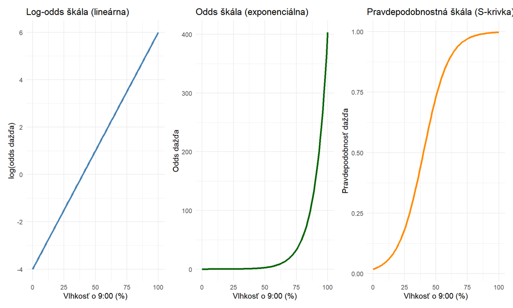

Vzťah medzi vlhkosťou a dažďom na rôznych škálach

```r
# Vizualizácia rôznych škál
beta_0 <- -4
beta_1 <- 0.1
x <- seq(0, 100, by = 1)

df_scales <- tibble(
  humidity = x,
  log_odds = beta_0 + beta_1 * x,
  odds = exp(log_odds),
  probability = odds / (1 + odds)
)

# Grafy
p1 <- ggplot(df_scales, aes(x = humidity, y = log_odds)) +
  geom_line(color = "steelblue", linewidth = 1.2) +
  labs(x = "Vlhkosť o 9:00 (%)", y = "log(odds dažďa)",
       title = "Log-odds škála (lineárna)") +
  theme_minimal()

p2 <- ggplot(df_scales, aes(x = humidity, y = odds)) +
  geom_line(color = "darkgreen", linewidth = 1.2) +
  labs(x = "Vlhkosť o 9:00 (%)", y = "Odds dažďa",
       title = "Odds škála (exponenciálna)") +
  theme_minimal()

p3 <- ggplot(df_scales, aes(x = humidity, y = probability)) +
  geom_line(color = "darkorange", linewidth = 1.2) +
  labs(x = "Vlhkosť o 9:00 (%)", y = "Pravdepodobnosť dažďa",
       title = "Pravdepodobnostná škála (S-krivka)") +
  theme_minimal()

library(patchwork)
p1 + p2 + p3
```

## 3.4 Interpretácia koeficientov logistickej regresie

> **Interpretácia $\beta_0$ (intercept):**

> Keď všetky prediktory $(X_1, X_2, \ldots, X_p) = 0$:
> - $\beta_0$ je log(odds) udalosti
> - $e^{\beta_0}$ sú odds udalosti

> **Interpretácia $\beta_1$ (sklon):**

> Pri kontrole ostatných prediktorov, keď sa $X_1$ zvýši o 1:
> - $\beta_1$ je zmena v log(odds)
> - $e^{\beta_1}$ je **multiplikatívna zmena** v odds

> $$\beta_1 = \log(\text{odds}_{x+1}) -
> \log(\text{odds}_x)$$
> $$e^{\beta_1} =
> \frac{\text{odds}_{x+1}}{\text{odds}_x}$$

**Príklad s $\beta_0 = -4$ a $\beta_1 = 0.1$:**

Pri vlhkosti 0%:
$$\text{odds dažďa} =
e^{-4} = 0.0183$$
$$\text{pravdepodobnosť dažďa} = \frac{e^{-4}}{1 +
e^{-4}} = 0.018$$

Pre každý 1% nárast vlhkosti:
$$\text{multiplikatívna zmena odds} = e^{0.1} =
1.11$$

**Interpretácia:** Odds dažďa sa zvyšujú o 11% s každým percentuálnym bodom vlhkosti.

## 3.5 Špecifikácia apriorných rozdelení

Pre koeficienty logistickej regresie použijeme normálne apriorné rozdelenia:

$$\begin{aligned}
\text{dáta:} \quad & Y_i|\beta_0,\beta_1 \stackrel{ind}{\sim}
\text{Bern}(\pi_i) \text{ kde } \log\left(\frac{\pi_i}{1 - \pi_i}\right)
= \beta_0 + \beta_1 X_{i1} \\
\text{apriórne:} \quad & \beta_{0c} \sim N(-1.4, 0.7^2) \\
& \beta_1 \sim N(0.07, 0.035^2)
\end{aligned}$$

### 3.5.1 Odôvodnenie apriorného rozdelenia pre $\beta_{0c}$

Máme apriorný odhad, že priemerný deň má ~20% šancu na dážď:

$$\log\left(\frac{0.2}{1-0.2}\right) =
\log(0.25) \approx -1.4$$

Apriorný 95% interval pre $\beta_{0c}$: $(-1.4 \pm 2 \times 0.7) = (-2.8, 0)$

Na odds škále: $(e^{-2.8}, e^{0}) = (0.06, 1)$

Na pravdepodobnostnej škále: $(0.057, 0.50)$

### 3.5.2 Simulácia z apriorného rozdelenia

```r
# Apriorná simulácia
rain_model_prior <- stan_glm(
  raintomorrow ~ humidity9am,
  data = weather,
  family = binomial,
  prior_intercept = normal(-1.4, 0.7),
  prior = normal(0.07, 0.035),
  chains = 4,
  iter = 5000*2,
  seed = 84735,
  prior_PD = TRUE,  # Len apriorná simulácia
  refresh = 0
)
```

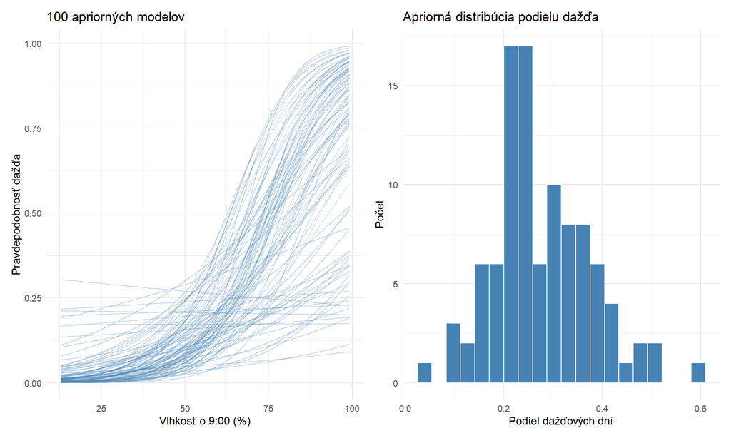

Apriorné prediktívne simulácie

```r
set.seed(84735)

# Graf 100 apriorných modelov
p_prior_models <- weather %>%
  add_fitted_draws(rain_model_prior, n = 100) %>%
  ggplot(aes(x = humidity9am, y = raintomorrow)) +
  geom_line(aes(y = .value, group = .draw), alpha = 0.3, color = "steelblue") +
  labs(x = "Vlhkosť o 9:00 (%)",
       y = "Pravdepodobnosť dažďa",
       title = "100 apriorných modelov") +
  theme_minimal()

# Apriorná distribúcia podielu dažďových dní
p_prior_rain <- weather %>%
  add_predicted_draws(rain_model_prior, n = 100) %>%
  group_by(.draw) %>%
  summarize(proportion_rain = mean(.prediction == 1)) %>%
  ggplot(aes(x = proportion_rain)) +
  geom_histogram(fill = "steelblue", color = "white", bins = 20) +
  labs(x = "Podiel dažďových dní",
       y = "Počet",
       title = "Apriorná distribúcia podielu dažďa") +
  theme_minimal()

p_prior_models + p_prior_rain
```

# 4 Simulácia posteriorného rozdelenia

## 4.1 Exploratívna analýza dát

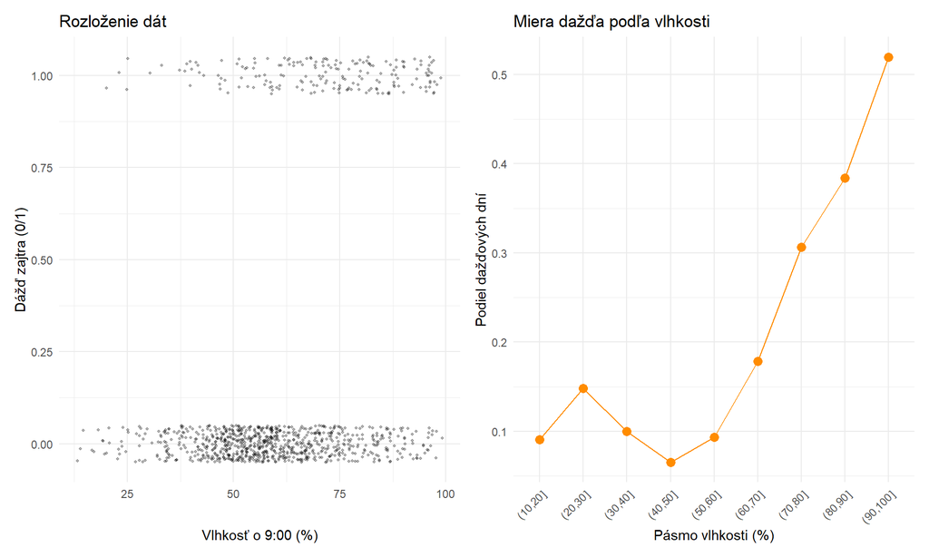

Exploratívna analýza vzťahu dažďa a vlhkosti

```r
# Jitter plot
p_jitter <- ggplot(weather, aes(x = humidity9am, y = as.numeric(raintomorrow == "Yes"))) +
  geom_jitter(height = 0.05, alpha = 0.3, size = 0.8) +
  labs(x = "Vlhkosť o 9:00 (%)", y = "Dážď zajtra (0/1)",
       title = "Rozloženie dát") +
  theme_minimal()

# Miera dažďa podľa pásiem vlhkosti
p_rate <- weather %>%
  mutate(humidity_bracket = cut(humidity9am, breaks = seq(10, 100, by = 10))) %>%
  group_by(humidity_bracket) %>%
  summarize(rain_rate = mean(raintomorrow == "Yes"), n = n()) %>%
  ggplot(aes(x = humidity_bracket, y = rain_rate)) +
  geom_point(size = 3, color = "darkorange") +
  geom_line(aes(group = 1), color = "darkorange") +
  labs(x = "Pásmo vlhkosti (%)", y = "Podiel dažďových dní",
       title = "Miera dažďa podľa vlhkosti") +
  theme_minimal() +
  theme(axis.text.x = element_text(angle = 45, hjust = 1))

p_jitter + p_rate
```

## 4.2 Posteriorná simulácia

```r
# Posteriorná simulácia
rain_model_1 <- update(rain_model_prior, prior_PD = FALSE, refresh = 0)
```

## 4.3 MCMC diagnostika

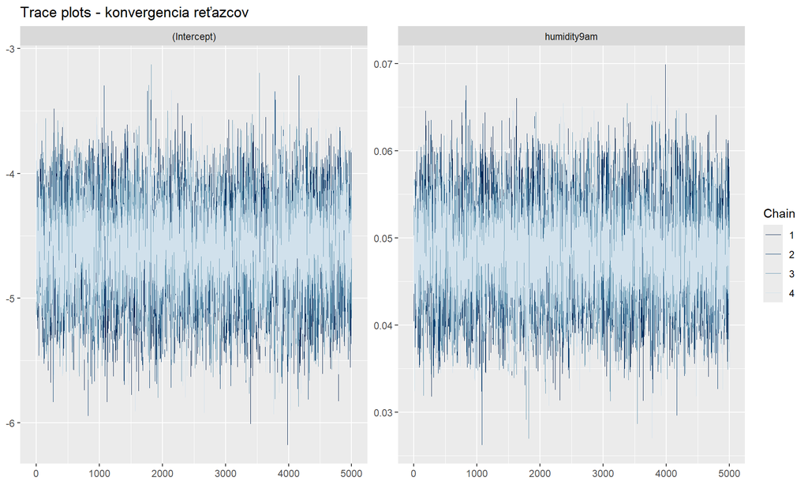

MCMC diagnostika

```r
# Trace plots
mcmc_trace(rain_model_1) +
  ggtitle("Trace plots - konvergencia reťazcov")
```

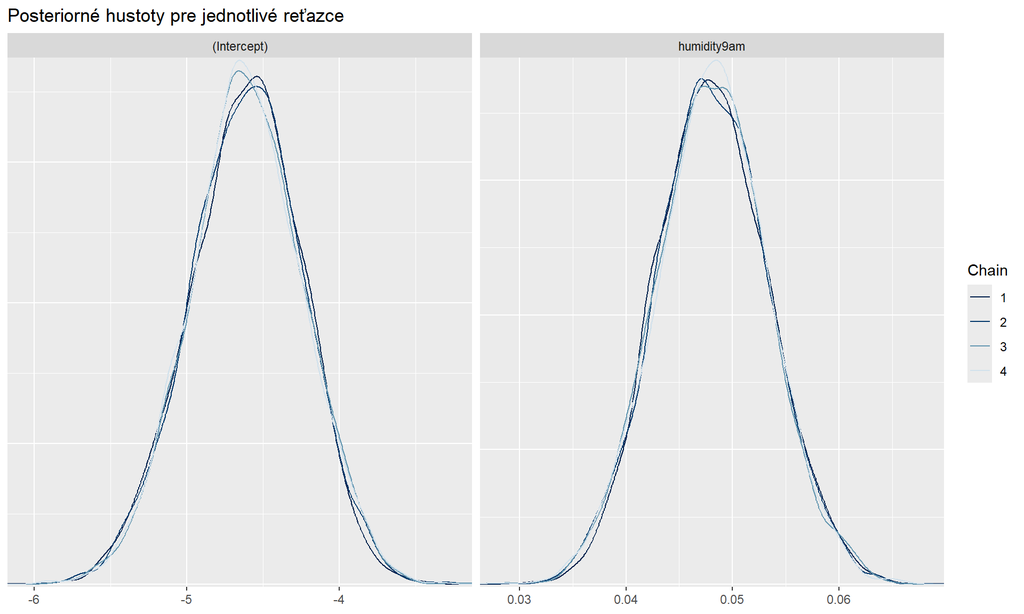

Posteriorné hustoty

```r
# Density plots
mcmc_dens_overlay(rain_model_1) +
  ggtitle("Posteriorné hustoty pre jednotlivé reťazce")
```

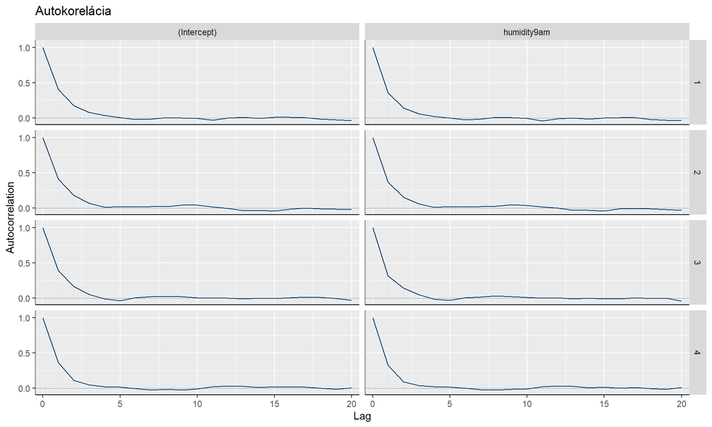

Autokorelácia

```r
# Autocorrelation
mcmc_acf(rain_model_1) +
  ggtitle("Autokorelácia")
```

## 4.4 Posteriorné modely

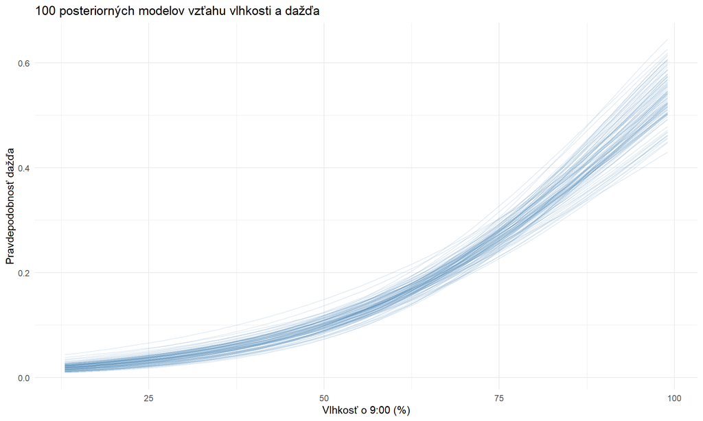

100 posteriorných modelov

```r
weather %>%
  add_fitted_draws(rain_model_1, n = 100) %>%
  ggplot(aes(x = humidity9am, y = as.numeric(raintomorrow == "Yes"))) +
  geom_line(aes(y = .value, group = .draw), alpha = 0.15, color = "steelblue") +
  labs(x = "Vlhkosť o 9:00 (%)",
       y = "Pravdepodobnosť dažďa",
       title = "100 posteriorných modelov vzťahu vlhkosti a dažďa") +
  theme_minimal()
```

## 4.5 Posteriorné súhrny

```r
# Súhrn na log-odds škále
cat("=== Posteriorné intervaly na log(odds) škále ===\n")
```

```
## === Posteriorné intervaly na log(odds) škále ===
```

```r
posterior_interval(rain_model_1, prob = 0.80)
```

```
##                     10%         90%
## (Intercept) -5.08784667 -4.13449813
## humidity9am  0.04146719  0.05487265
```

```r
# Súhrn na odds škále
cat("\n=== Posteriorné intervaly na odds škále ===\n")
```

```
##
## === Posteriorné intervaly na odds škále ===
```

```r
exp(posterior_interval(rain_model_1, prob = 0.80))
```

```
##                     10%       90%
## (Intercept) 0.006171294 0.0160107
## humidity9am 1.042338958 1.0564061
```

```r
# Tidy súhrn
tidy(rain_model_1, effects = "fixed", conf.int = TRUE, conf.level = 0.80)
```

```
## # A tibble: 2 × 5
##   term        estimate std.error conf.low conf.high
##   <chr>          <dbl>     <dbl>    <dbl>     <dbl>
## 1 (Intercept)  -4.60     0.367    -5.09     -4.13
## 2 humidity9am   0.0481   0.00523   0.0415    0.0549
```

**Interpretácia koeficientu $\beta_1$ (humidity9am):**

S 80% posteriornou pravdepodobnosťou:

- Na log(odds) škále: pre každý 1% nárast vlhkosti sa log(odds) dažďa zvyšuje o 0.041 až 0.055
- Na odds škále: pre každý 1% nárast vlhkosti sa odds dažďa zvyšujú o **4.2% až 5.6%**
- Pre každých 15% nárastu vlhkosti sa odds dažďa približne **zdvojnásobia**: $(e^{15 \times 0.041}, e^{15 \times 0.055}) = (1.86, 2.28)$

# 5 Predikcia a klasifikácia

## 5.1 Posteriorná predikcia pre nové pozorovanie

Predpokladajme, že dnes bola vlhkosť 99%. Chceme predpovedať, či bude zajtra pršať.

$$Y | \beta_0, \beta_1 \sim
\text{Bern}(\pi) \text{ kde } \log\left( \frac{\pi}{1-\pi}\right) =
\beta_0 + \beta_1 \times 99$$

```r
# Posteriorná predikcia binárneho výsledku
set.seed(84735)
binary_prediction <- posterior_predict(
  rain_model_1,
  newdata = data.frame(humidity9am = 99)
)

# Súhrn predikcií
cat("=== Posteriorná predikcia pre vlhkosť 99% ===\n")
```

```
## === Posteriorná predikcia pre vlhkosť 99% ===
```

```r
table(binary_prediction)
```

```
## binary_prediction
##     0     1
##  9196 10804
```

```r
cat("\nPodiel predikcií s dažďom:", mean(binary_prediction), "\n")
```

```
##
## Podiel predikcií s dažďom: 0.5402
```

## 5.2 Manuálna simulácia predikcie

```r
# Posteriorná predikcia - manuálne
set.seed(84735)
rain_model_1_df <- as.data.frame(rain_model_1) %>%
  mutate(
    log_odds = `(Intercept)` + humidity9am * 99,
    odds = exp(log_odds),
    prob = odds / (1 + odds),
    Y = rbinom(n(), size = 1, prob = prob)
  )

# Ukážka prvých riadkov
head(rain_model_1_df, 5)
```

```
##   (Intercept) humidity9am    log_odds      odds      prob Y
## 1   -4.244453  0.04454776  0.16577499 1.1803075 0.5413491 0
## 2   -4.207118  0.04209875 -0.03934156 0.9614223 0.4901659 1
## 3   -3.899987  0.03877941 -0.06082497 0.9409879 0.4847984 0
## 4   -3.942503  0.03948000 -0.03398243 0.9665885 0.4915052 1
## 5   -4.743743  0.05139157  0.34402150 1.4106090 0.5851671 0
```

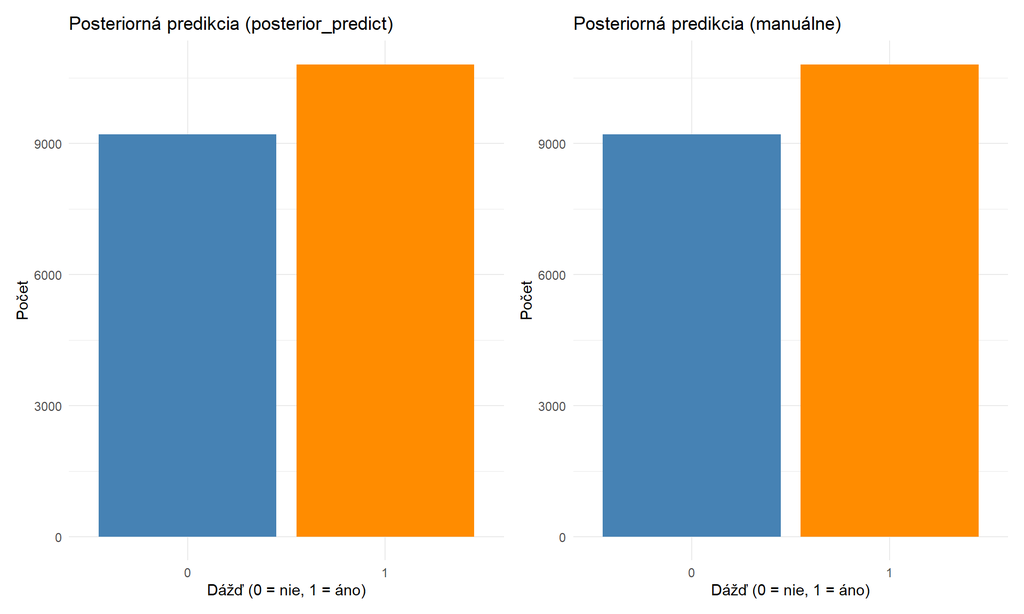

Posteriorné prediktívne rozdelenie

```r
# Vizualizácia
p1 <- ggplot(data.frame(Y = as.factor(binary_prediction[,1])), aes(x = Y)) +
  geom_bar(fill = c("steelblue", "darkorange")) +
  labs(x = "Dážď (0 = nie, 1 = áno)", y = "Počet",
       title = "Posteriorná predikcia (posterior_predict)") +
  theme_minimal()

p2 <- ggplot(rain_model_1_df, aes(x = as.factor(Y))) +
  geom_bar(fill = c("steelblue", "darkorange")) +
  labs(x = "Dážď (0 = nie, 1 = áno)", y = "Počet",
       title = "Posteriorná predikcia (manuálne)") +
  theme_minimal()

p1 + p2
```

## 5.3 Klasifikačné pravidlo

> **Klasifikačné pravidlo:**

> Nech $Y$ je binárna premenná (1 alebo 0), nech $(Y_{new}^{(1)}, Y_{new}^{(2)}, \ldots, Y_{new}^{(N)})$ sú $N$ posteriorných predikcií a $p$ je podiel predikcií kde $Y_{new}^{(i)} = 1$.

> Pre zvolený klasifikačný prah $c \in [0,1]$:
> - Ak $p \geq c$, klasifikuj $Y$ ako 1
> - Ak $p < c$, klasifikuj $Y$ ako 0

**Voľba prahu $c$:**

- $c = 0.5$ (štandardný) - klasifikuj podľa väčšiny
- $c < 0.5$ - zvýši citlivosť (sensitivity), zníži špecificitu
- $c > 0.5$ - zvýši špecificitu (specificity), zníži citlivosť

# 6 Evaluácia modelu

## 6.1 Posteriorná prediktívna kontrola

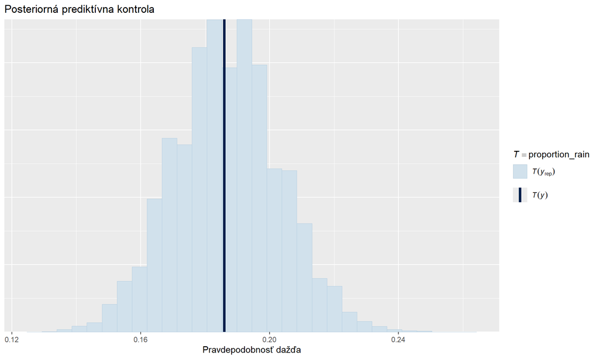

Posteriorná prediktívna kontrola

```r
# Funkcia na výpočet podielu dažďa
proportion_rain <- function(x) mean(x == 1)

# PP check
pp_check(rain_model_1, nreps = 100,
         plotfun = "stat", stat = "proportion_rain") +
  xlab("Pravdepodobnosť dažďa") +
  ggtitle("Posteriorná prediktívna kontrola")
```

## 6.2 Klasifikačná presnosť

### 6.2.1 Definície metrík

> **Confusion matrix a metriky presnosti:**

> |  | $\hat{Y} = 0$ | $\hat{Y} = 1$ |
> | --- | --- | --- |
> | $Y = 0$ | a (True Negative) | b (False Positive) |
> | $Y = 1$ | c (False Negative) | d (True Positive) |

> **Celková presnosť (Overall accuracy):**
> $$\text{accuracy} = \frac{a + d}{a + b + c +
> d}$$

> **Citlivosť (Sensitivity / True Positive Rate):**
> $$\text{sensitivity} = \frac{d}{c + d}$$

> **Špecificita (Specificity / True Negative Rate):**
> $$\text{specificity} = \frac{a}{a +
> b}$$

### 6.2.2 In-sample klasifikácia

```r
# Posteriorné predikcie pre všetky dni v datasete
set.seed(84735)
rain_pred_1 <- posterior_predict(rain_model_1, newdata = weather)

# Klasifikácia s prahom 0.5
weather_classifications <- weather %>%
  mutate(
    rain_prob = colMeans(rain_pred_1),
    rain_class_05 = as.numeric(rain_prob >= 0.5),
    rain_class_02 = as.numeric(rain_prob >= 0.2)
  ) %>%
  select(humidity9am, rain_prob, rain_class_05, rain_class_02, raintomorrow)

# Ukážka
head(weather_classifications, 10)
```

```
## # A tibble: 10 × 5
##    humidity9am rain_prob rain_class_05 rain_class_02 raintomorrow
##          <int>     <dbl>         <dbl>         <dbl> <fct>
##  1          55    0.122              0             0 No
##  2          43    0.0739             0             0 No
##  3          62    0.163              0             0 Yes
##  4          53    0.116              0             0 No
##  5          65    0.186              0             0 No
##  6          84    0.362              0             1 No
##  7          48    0.0925             0             0 No
##  8          51    0.106              0             0 No
##  9          47    0.0860             0             0 Yes
## 10          90    0.431              0             1 Yes
```

```r
# Confusion matrix pre prah 0.5
cat("=== Confusion matrix (prah = 0.5) ===\n")
```

```
## === Confusion matrix (prah = 0.5) ===
```

```r
weather_classifications %>%
  tabyl(raintomorrow, rain_class_05) %>%
  adorn_totals(c("row", "col"))
```

```
##  raintomorrow   0  1 Total
##            No 803 11   814
##           Yes 172 14   186
##         Total 975 25  1000
```

```r
# Klasifikačný súhrn s prahom 0.5
set.seed(84735)
cat("\n=== Klasifikačná presnosť (prah = 0.5) ===\n")
```

```
##
## === Klasifikačná presnosť (prah = 0.5) ===
```

```r
classification_summary(model = rain_model_1, data = weather, cutoff = 0.5)
```

```
## $confusion_matrix
##    y   0  1
##   No 803 11
##  Yes 172 14
##
## $accuracy_rates
##
## sensitivity      0.07526882
## specificity      0.98648649
## overall_accuracy 0.81700000
```

**Interpretácia (prah = 0.5):**

- **Celková presnosť:** 81.7% - zdanlivo dobrá
- **Špecificita:** 98.65% - výborne predpovedáme, keď NEBUDE pršať
- **Citlivosť:** 7.53% - VEĽMI ZLÉ pri predpovedi dažďa!

### 6.2.3 Úprava klasifikačného prahu

```r
# Klasifikačný súhrn s prahom 0.2
set.seed(84735)
cat("=== Klasifikačná presnosť (prah = 0.2) ===\n")
```

```
## === Klasifikačná presnosť (prah = 0.2) ===
```

```r
classification_summary(model = rain_model_1, data = weather, cutoff = 0.2)
```

```
## $confusion_matrix
##    y   0   1
##   No 580 234
##  Yes  67 119
##
## $accuracy_rates
##
## sensitivity      0.6397849
## specificity      0.7125307
## overall_accuracy 0.6990000
```

**Interpretácia (prah = 0.2):**

- **Citlivosť:** vzrástla z 7.53% na 63.98%
- **Špecificita:** klesla z 98.65% na 71.25%
- **Trade-off:** Lepšie predpovedáme dážď, ale častejšie zbytočne nosíme dáždnik

### 6.2.4 Krížová validácia

```r
# 10-násobná krížová validácia
set.seed(84735)
cv_accuracy_1 <- classification_summary_cv(
  model = rain_model_1,
  data = weather,
  cutoff = 0.2,
  k = 10
)

cat("=== Krížovo-validovaná presnosť (prah = 0.2) ===\n")
```

```
## === Krížovo-validovaná presnosť (prah = 0.2) ===
```

```r
cv_accuracy_1$cv
```

```
##   sensitivity specificity overall_accuracy
## 1   0.6533708   0.7185146            0.705
```

> **Trade-off medzi citlivosťou a špecificitou:**
> - Keď **znížime** prah $c$: citlivosť **rastie**, špecificita **klesá**
> - Keď **zvýšime** prah $c$: špecificita **rastie**, citlivosť **klesá**

# 7 Rozšírenie modelu

## 7.1 Model s viacerými prediktormi

Rozšírime model o ďalšie prediktory:

- $X_1$ = vlhkosť o 9:00 (humidity9am)
- $X_2$ = vlhkosť o 15:00 (humidity3pm)
- $X_3$ = či dnes pršalo (raintoday)

$$\log\left(\frac{\pi_i}{1-\pi_i}\right) =
\beta_0 + \beta_1 X_{i1} + \beta_2 X_{i2} + \beta_3 X_{i3}$$

### 7.1.1 Špecifikácia modelu

$$\begin{aligned}
Y_i | \beta_0, \beta_1, \beta_2, \beta_3 & \sim \text{Bern}(\pi_i)
\\
\log\left(\frac{\pi_i}{1-\pi_i}\right) &= \beta_0 + \beta_1 X_{i1} +
\beta_2 X_{i2} + \beta_3 X_{i3} \\
\beta_{0c} & \sim N(-1.4, 0.7^2) \\
\beta_1 & \sim N(0, 0.14^2) \\
\beta_2 & \sim N(0, 0.15^2) \\
\beta_3 & \sim N(0, 6.45^2)
\end{aligned}$$

```r
# Model s viacerými prediktormi
rain_model_2 <- stan_glm(
  raintomorrow ~ humidity9am + humidity3pm + raintoday,
  data = weather,
  family = binomial,
  prior_intercept = normal(-1.4, 0.7),
  prior = normal(0, 2.5, autoscale = TRUE),
  chains = 4,
  iter = 5000*2,
  seed = 84735,
  refresh = 0
)

# Apriorné rozdelenia
prior_summary(rain_model_2)
```

```
## Priors for model 'rain_model_2'
## ------
## Intercept (after predictors centered)
##  ~ normal(location = -1.4, scale = 0.7)
##
## Coefficients
##   Specified prior:
##     ~ normal(location = [0,0,0], scale = [2.5,2.5,2.5])
##   Adjusted prior:
##     ~ normal(location = [0,0,0], scale = [0.14,0.15,6.45])
## ------
## See help('prior_summary.stanreg') for more details
```

### 7.1.2 Posteriorné súhrny rozšíreného modelu

```r
# Posteriorné súhrny
tidy(rain_model_2, effects = "fixed", conf.int = TRUE, conf.level = 0.80)
```

```
## # A tibble: 4 × 5
##   term         estimate std.error conf.low conf.high
##   <chr>           <dbl>     <dbl>    <dbl>     <dbl>
## 1 (Intercept)  -5.46      0.483    -6.08    -4.85
## 2 humidity9am  -0.00693   0.00737  -0.0163   0.00251
## 3 humidity3pm   0.0796    0.00846   0.0689   0.0906
## 4 raintodayYes  1.15      0.220     0.874    1.44
```

**Interpretácia koeficientov:**

1. **humidity3pm** ($\beta_2$): 80% CI je nad 0 → významný prediktor
   - $e^{0.0796} = 1.083$ → pre každý 1% nárast popoludňajšej vlhkosti sa odds dažďa zvyšujú o ~8%
2. **raintodayYes** ($\beta_3$): 80% CI je nad 0 → významný prediktor
   - $e^{1.15} = 3.17$ → ak dnes prší, odds dažďa zajtra sa **viac ako strojnásobia**
3. **humidity9am** ($\beta_1$): 80% CI obsahuje 0 → NEVÝZNAMNÝ keď kontrolujeme ostatné prediktory
   - To neznamená, že ranná vlhkosť nesúvisí s dažďom
   - Znamená to, že informácia z `humidity9am` je **redundantná** keď už poznáme `humidity3pm` a `raintoday`

### 7.1.3 Porovnanie modelov

```r
# Krížová validácia pre oba modely
set.seed(84735)
cv_accuracy_2 <- classification_summary_cv(
  model = rain_model_2,
  data = weather,
  cutoff = 0.2,
  k = 10
)

cat("=== Porovnanie krížovo-validovanej presnosti ===\n")
```

```
## === Porovnanie krížovo-validovanej presnosti ===
```

```r
cat("\nModel 1 (len humidity9am):\n")
```

```
##
## Model 1 (len humidity9am):
```

```r
cv_accuracy_1$cv
```

```
##   sensitivity specificity overall_accuracy
## 1   0.6533708   0.7185146            0.705
```

```r
cat("\nModel 2 (humidity9am + humidity3pm + raintoday):\n")
```

```
##
## Model 2 (humidity9am + humidity3pm + raintoday):
```

```r
cv_accuracy_2$cv
```

```
##   sensitivity specificity overall_accuracy
## 1   0.7521557   0.8139202            0.802
```

```r
# Porovnanie ELPD
loo_1 <- loo(rain_model_1)
loo_2 <- loo(rain_model_2)

cat("=== Porovnanie ELPD ===\n")
```

```
## === Porovnanie ELPD ===
```

```r
loo_compare(loo_1, loo_2)
```

```
##              elpd_diff se_diff
## rain_model_2   0.0       0.0
## rain_model_1 -80.2      13.5
```

**Záver:** Model 2 je lepší - vyššia citlivosť, špecificita aj celková presnosť.

# 8 Súhrn kapitoly

## 8.1 Model Bayesovskej logistickej regresie

Pre binárnu závislú premennú $Y \in \{0, 1\}$ a prediktory $(X_1, X_2, \ldots, X_p)$:

$$\begin{aligned}
\text{dáta:} \quad & Y_i|\beta_0,\beta_1,\ldots,\beta_p
\stackrel{ind}{\sim} \text{Bern}(\pi_i) \\
& \text{kde } \log\left(\frac{\pi_i}{1 - \pi_i}\right) = \beta_0 +
\beta_1 X_{i1} + \cdots + \beta_p X_{ip} \\
\text{apriórne:} \quad & \beta_{0c} \sim N(m_0, s_0^2) \\
& \beta_{1} \sim N(m_1, s_1^2) \\
& \vdots \\
& \beta_{p} \sim N(m_p, s_p^2)
\end{aligned}$$

## 8.2 Transformácie

**Z log(odds) na odds:**
$$\frac{\pi_i}{1-\pi_i} = e^{\beta_0 + \beta_1
X_{i1} + \cdots + \beta_p X_{ip}}$$

**Z log(odds) na pravdepodobnosť:**
$$\pi_i = \frac{e^{\beta_0 + \beta_1 X_{i1} +
\cdots + \beta_p X_{ip}}}{1 + e^{\beta_0 + \beta_1 X_{i1} + \cdots +
\beta_p X_{ip}}}$$

## 8.3 Kľúčové koncepty

| Koncept | Popis |
| --- | --- |
| **Odds** | $\frac{\pi}{1-\pi}$ - pomer pravdepodobností |
| **Logit link** | $\log\left(\frac{\pi}{1-\pi}\right)$ - transformácia na reálnu os |
| **Sensitivity** | Schopnosť správne identifikovať $Y=1$ |
| **Specificity** | Schopnosť správne identifikovať $Y=0$ |
| **Classification cutoff** | Prah pre binárnu klasifikáciu |

## 8.4 Workflow Bayesovskej logistickej regresie

1. **Špecifikuj model** - Bernoulliho rozdelenie + logit link
2. **Nastav apriorné rozdelenia** - simuluj a skontroluj
3. **Simuluj posteriorné rozdelenie** - pomocou `stan_glm(family = binomial)`
4. **Skontroluj MCMC diagnostiku** - trace plots, density, autocorrelation
5. **Interpretuj koeficienty** - na log(odds), odds a pravdepodobnostnej škále
6. **Predikuj a klasifikuj** - zvol vhodný prah
7. **Evaluuj model** - sensitivity, specificity, CV, ELPD

# 9 Užitočné funkcie

```r
# Logistická regresia v rstanarm
stan_glm(y ~ x1 + x2, data = data, family = binomial,
         prior_intercept = normal(m0, s0),
         prior = normal(m, s, autoscale = TRUE), refresh = 0)

# Posteriorné intervaly
posterior_interval(model, prob = 0.80)

# Transformácia na odds
exp(posterior_interval(model, prob = 0.80))

# Posteriorná predikcia
posterior_predict(model, newdata = new_data)

# Klasifikačná presnosť
classification_summary(model, data, cutoff = 0.5)

# Krížová validácia
classification_summary_cv(model, data, cutoff = 0.5, k = 10)

# Porovnanie modelov
loo_compare(loo(model_1), loo(model_2))
```

*Materiál vytvorený podľa: Johnson, A. A., Ott, M. Q., & Dogucu, M. (2022). Bayes Rules! An Introduction to Applied Bayesian Modeling. CRC Press.*